# Part II - (Dataset Exploration of Fordgobike Share Trip in San Francisco)

## by (Ismaila Abdullahi Adavize)

## Investigation Overview

> Does the bike share trip depends on if the user type is costumer or subscriber Does gender affect the bike share trip for riders How does age depend on how fast the riders finish the trip providing the bike share trip make me to understand the insight between the dataset variable

## Dataset Overview

> the dataset has 183412 variables and 16 features, the features include (duration_sec, start_time, end_time, start_station_id, start_station_name, start_station_latitude, start_station_longitude, end_station_id, end_station_name, end_station_latitude, end_station_longitude, bike_id, user_type, member_birth_year, member_gender, bike_share_for_all_trip) after my wrangling process there was a total of 174952 rows and 18 columns adding two columns (age and age_group)

```python
# import all packages and set plots to be embedded inline
import numpy as np
import pandas as pd
import matplotlib.pyplot as plt
import seaborn as sb
%matplotlib inline

# suppress warnings from final output
import warnings
warnings.simplefilter("ignore")
```

```python
# load in the dataset into a pandas dataframe
fordgobike_clean = pd.read_csv('fordgobike_clean.csv')
fordgobike_clean.sample(5)
```

|  | duration_sec | start_time | end_time | start_station_id | start_station_name | start_station_latitude | start_station_longitude | end_station_id | end_station_name | end_station_latitude | end_station_longitude | bike_id | user_type | member_birth_year | member_gender | bike_share_for_all_trip | Age | age_groups |
| --- | --- | --- | --- | --- | --- | --- | --- | --- | --- | --- | --- | --- | --- | --- | --- | --- | --- | --- |
| 152172 | 306 | 2019-02-05 17:59:03.7260 | 2019-02-05 18:04:10.7110 | 241.0 | Ashby BART Station | 37.852477 | -122.270213 | 242.0 | Milvia St at Derby St | 37.860125 | -122.269384 | 3365 | Subscriber | 1993.0 | Male | No | 26 | youths |
| 36531 | 254 | 2019-02-23 12:43:21.1760 | 2019-02-23 12:47:35.8840 | 274.0 | Oregon St at Adeline St | 37.857567 | -122.267558 | 266.0 | Parker St at Fulton St | 37.862464 | -122.264791 | 2051 | Subscriber | 1998.0 | Male | Yes | 21 | youths |
| 78510 | 785 | 2019-02-18 11:12:46.1830 | 2019-02-18 11:25:51.4820 | 270.0 | Ninth St at Heinz Ave | 37.853489 | -122.289415 | 176.0 | MacArthur BART Station | 37.828410 | -122.266315 | 5104 | Subscriber | 1991.0 | Male | No | 28 | youths |
| 126178 | 390 | 2019-02-09 08:42:26.6150 | 2019-02-09 08:48:56.8870 | 356.0 | Valencia St at Clinton Park | 37.769188 | -122.422285 | 121.0 | Mission Playground | 37.759210 | -122.421339 | 5474 | Customer | 1990.0 | Male | No | 29 | youths |
| 6490 | 808 | 2019-02-28 09:38:30.7440 | 2019-02-28 09:51:58.9050 | 59.0 | S Van Ness Ave at Market St | 37.774814 | -122.418954 | 22.0 | Howard St at Beale St | 37.789756 | -122.394643 | 4395 | Subscriber | 1987.0 | Female | No | 32 | adults |

## (Does the bike share trip depends on if the user type is costumer or subscriber)

> This is a multiple planatory visualiztion that shows the relationship between user_type, bike*share* for_all_trip the San francisco bar share trip has 158386 Subscriber and 16566 Customer

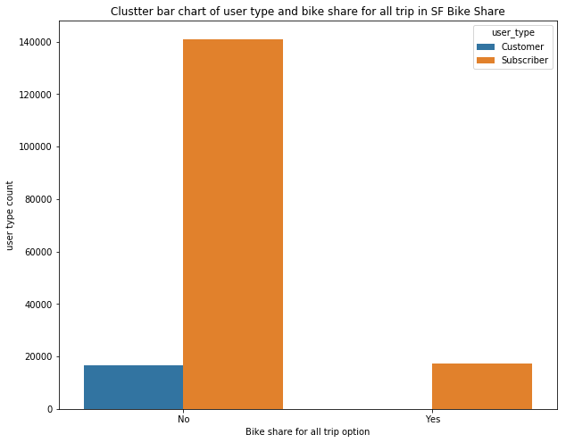

```python
#plotting a cluster bar chart to show the relationship between bike share for all trip and user type
plt.figure(figsize = [10,8])
sb.countplot(data = fordgobike_clean, x = 'bike_share_for_all_trip', hue = 'user_type')
plt.xticks(rotation = 0)
plt.ylabel('user type count')
plt.xlabel('Bike share for all trip option')
plt.title('Clustter bar chart of user type and bike share for all trip in SF Bike Share');
```

## (Does gender affect the bike share trip for riders in the Sans Francisco)

> Majority of the riders are of the Age bracket of 18 to 45 years. and the male is 130500, female is 40805 while other is 3647

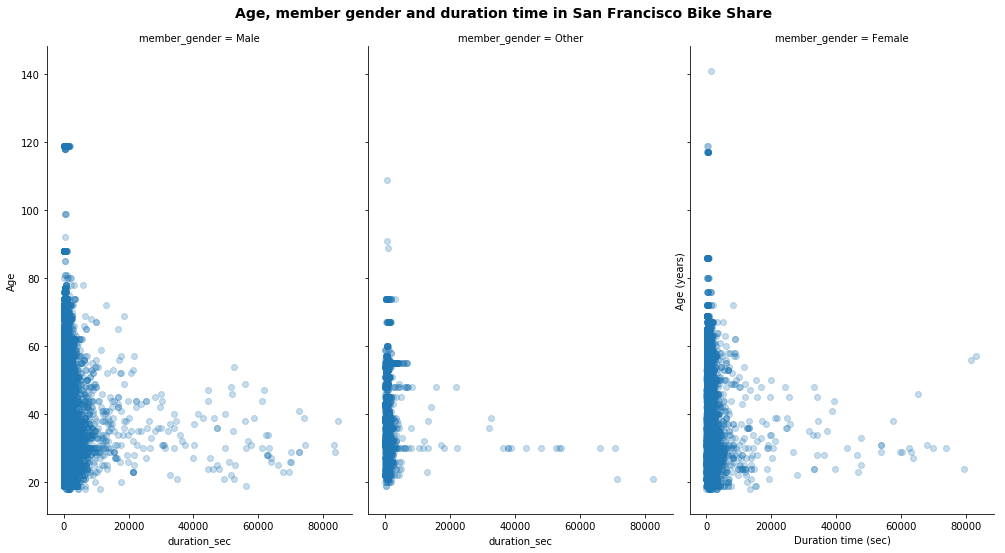

```python
# plotting a facetgrid graph of member gender, duration time in seconds and age
genders = sb.FacetGrid(data = fordgobike_clean, col = 'member_gender',col_wrap = 3, size = 5)
genders.map(plt.scatter, 'duration_sec', 'Age',alpha = 0.25)
genders.fig.set_size_inches(14,8);
plt.ylabel('Age (years)')
plt.xlabel('Duration time (sec)')
plt.suptitle('Age, member gender and duration time in San Francisco Bike Share',y = 1, fontsize = 14, weight = "bold");
plt.show()
```

## (How does age depend on how fast the riders finish the trip?)

> The highest duration time were from riders with about 18 to 45years of age

```python
#plotting a heap map of age against duration in second
plt.figure(figsize = [8, 6])
plt.hist2d(data = fordgobike_clean, x = 'duration_sec', y = 'Age', cmin = 0.5, cmap = 'viridis_r');
plt.colorbar()
plt.ylabel('Age(years)')
plt.xlabel(' duration seconds')
plt.title('heap map correlation between Duration and Age in San Francisco Bike Share trip');
plt.show()
```

[output not shown]

### Generate Slideshow

Once you're ready to generate your slideshow, use the `jupyter nbconvert` command to generate the HTML slide show.

```python
# Use this command if you are running this file in local
!jupyter nbconvert Part_II_project_fordgobike.ipynb --to slides --post serve --no-input --no-prompt
```